# EDA

Import libraries

```r
library(tidyverse)
library(ggplot2)
library(rmarkdown)
```

## Read in Data

```r
df <- read.csv("cafo-wq-data.csv")
```

## Initial EDA:

In order to construct an analysis plan and propose an appropriate model, we need to preform some exploratory data analysis.

Data structure: A lot of columns- can we filter any out?

```r
# function to get structure as data frame so it can be shown as paged output
str_as_df <- function(x) {
  data.frame(
    Variable = names(x),
    Class = sapply(x, function(col) paste(class(col), collapse = ", ")),
    Values = sapply(x, function(col) paste(head(col, n = 4), collapse = ", ")),
    row.names = NULL
  )
}

# apply function
df_str <- str_as_df(df)
paged_table(df_str)
```

| Variable | Class | Values |
| --- | --- | --- |
| station_id | character | B0050000, B0070010, B0170000, B0400000 |
| stationcategory | character | UCFR, UCFR, UCFR, UCFR |
| huc8id | integer | 3030002, 3030002, 3030002, 3030002 |
| huc10id | integer | 303000202, 303000202, 303000202, 303000201 |
| huc12id | numeric | 30300020204, 30300020203, 30300020206, 30300020107 |
| huc8_upstream_area_sqkm | numeric | 206.4241, 141.7031, 435.9061, 338.6729 |
| huc8_upstream_cafo_count | integer | 2, 4, 12, 2 |
| huc8_upstream_swine_cafo_count | integer | 0, 0, 1, 0 |
| huc8_upstream_poultry_cafo_count | integer | 0, 3, 6, 2 |
| huc8_upstream_other_cafo_count | integer | 2, 1, 5, 0 |

[output cut: 153 more lines]

Format date column

```r
df <- df |>
  mutate(date = format(mdy(date), "%m/%d/%Y"))
```

Check for missing values

Some variables have a lot of missing values- looks to be due to the spatial scales for some of them.

For the variables with missing values that are not related to spatial scales, do we need to remove those? Ex. ‘nearest_upstream_poultry_cafo_di’, response variables

```r
sum_na <- function(column){
 sum(is.na(column))
}

df |> summarize(across(everything(), sum_na))
```

[output not shown]

If we use the continuous versions of the response variables, should we log transform them?

Before looking at the linearity of the continuous response variables, we will look at the distribution to see if a log transformation is necessary. We ony need to look at nitrate/nitrate and phosphorus concentration, since it has already been determined that we should use log transformed fecal coliform counts.

Also should investigate the cause of the heavy right tails.

```r
par(mfrow = c(2, 2))

# raw variables
hist(df$no2no3mgl,
     main = 'Nitrate/nitrite',
     xlab = 'mg/L',
     breaks = 30)

hist(df$phosphorusmgl,
     main = 'Phosphorus',
     xlab = 'mg/L',
     breaks = 30)
```

[figure not shown]

```r
# log transformed variables
hist(df$nitlog,
     main = 'Log nitrate/nitrite',
     xlab = 'log value',
     breaks = 30)

hist(df$phoslog,
     main = 'Log phosphorus',
     xlab = 'log value',
     breaks = 30)
```

[output not shown]

Should we use the continuous or binary versions of the response variables?

Look at the relationship between each of the continuous response variables and one of the CAFO metrics to see if the relationship is linear

Use log transformed variables based on above result

I’m look at the 4 metrics for upstream poultry CAFOs as the independent variables initially. If needed, I will look at the relationships with other independent variables as well.

Would including any temporal or spatial variables explain some of these relationships? or any of the covariates? With so many variables, what is the best way to answer this question?

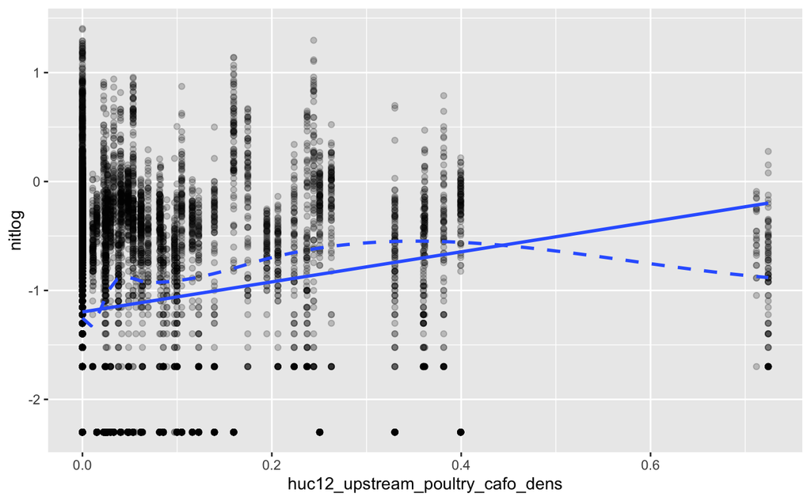

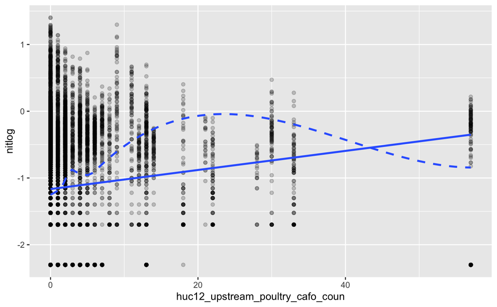

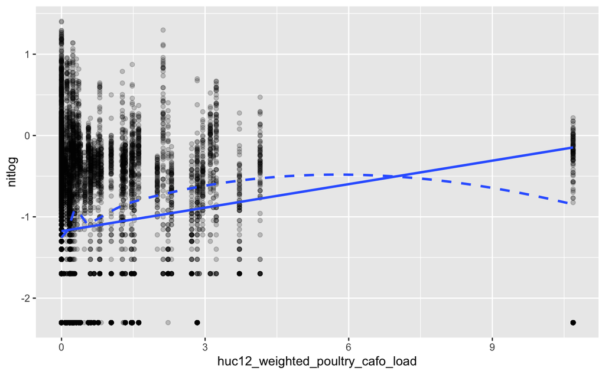

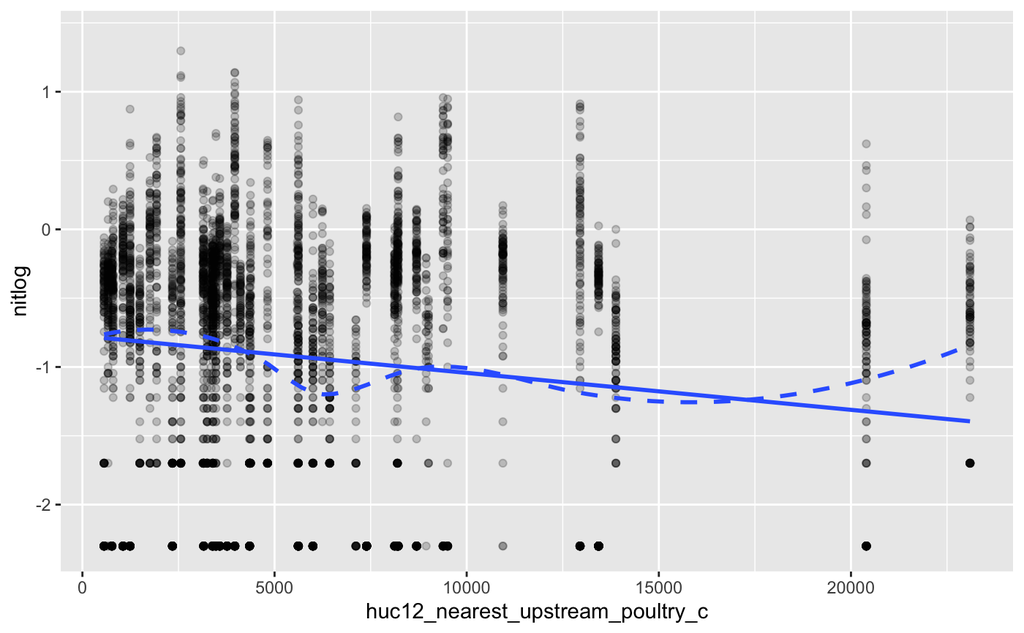

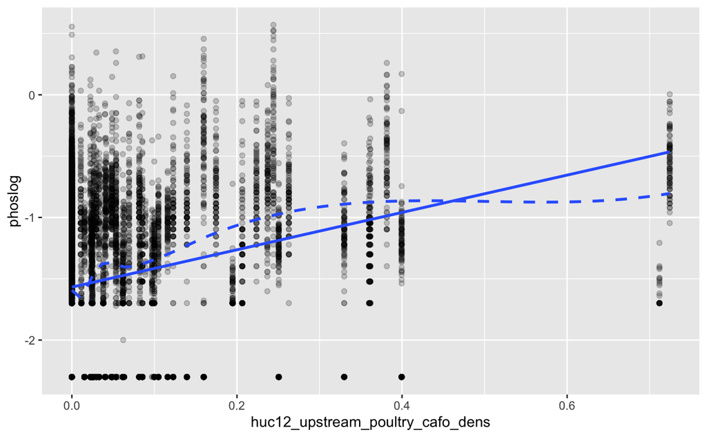

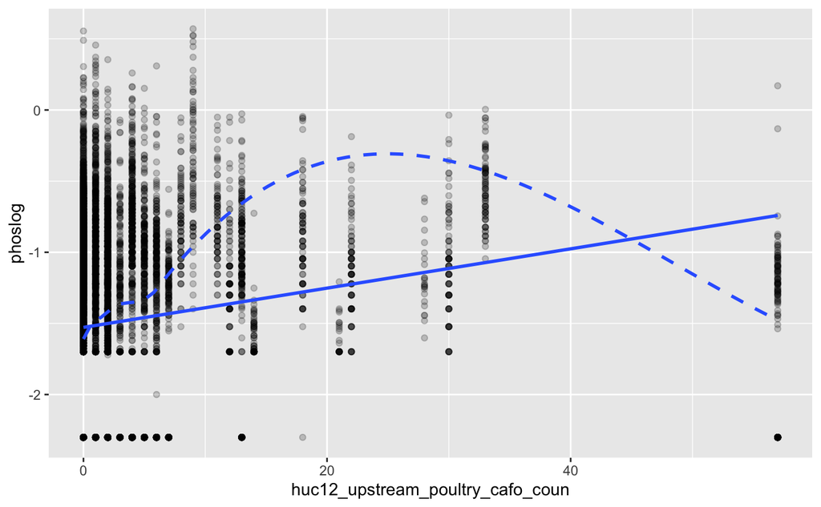

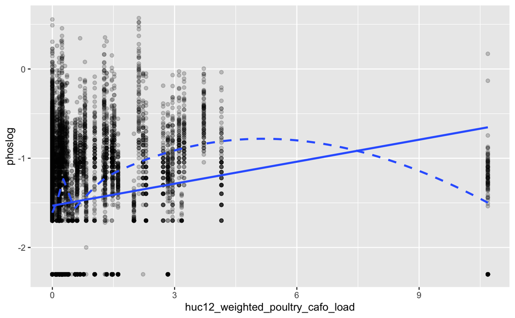

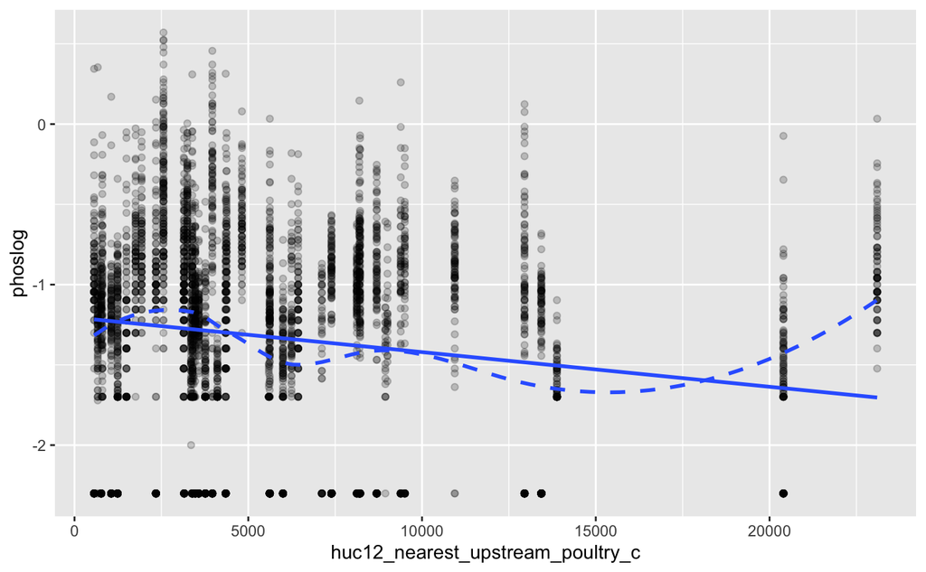

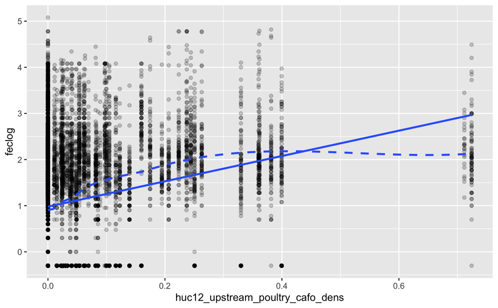

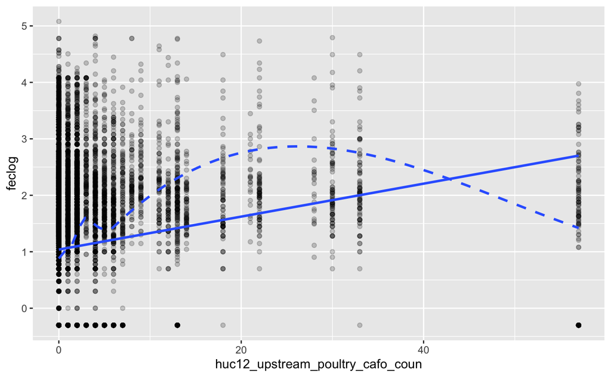

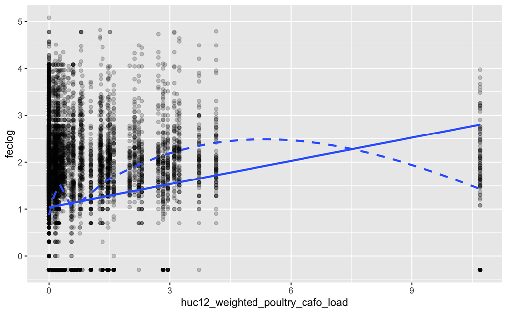

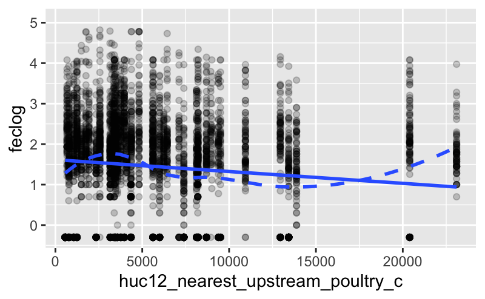

```r
# response vars
responses <- c('nitlog', 'phoslog', 'feclog')

# poultry CAFO metrics
metrics <- c(
  'huc12_upstream_poultry_cafo_dens',
  'huc12_upstream_poultry_cafo_coun',
  'huc12_weighted_poultry_cafo_load',
  'huc12_nearest_upstream_poultry_c'
)

# function to make plot for each x and y
make_plot <- function(data, x_var, y_var) {
  ggplot(data, aes(x = .data[[x_var]], y = .data[[y_var]])) +
    geom_point(alpha = 0.2) +
    geom_smooth(method = 'lm', formula = y ~ x, se = FALSE) +
    geom_smooth(method = 'loess', formula = y ~ x, se = FALSE, linetype = 'dashed') +
    labs(
      x = x_var,
      y = y_var
    )
}

# make all plots
plots <- list()

for (response in responses) {
  for (metric in metrics) {

    plots[[length(plots) + 1]] <- make_plot(
      data = df,
      x_var = metric,
      y_var = response
    )
  }
}

plots
```

Look at the same independent variables but for all CAFOs instead of just poultry to see if there is a difference in the strength of the relationship

Not a huge difference from just poultry CAFOs

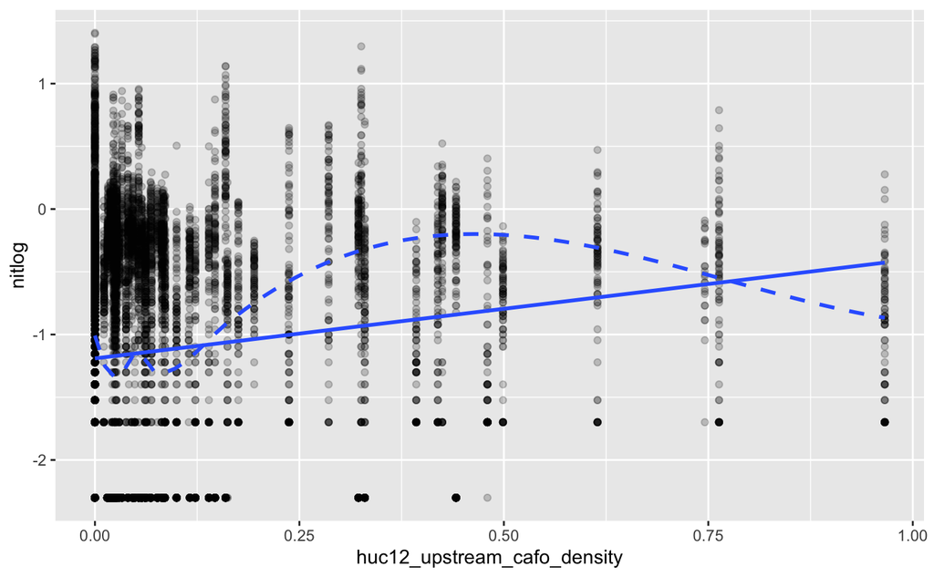

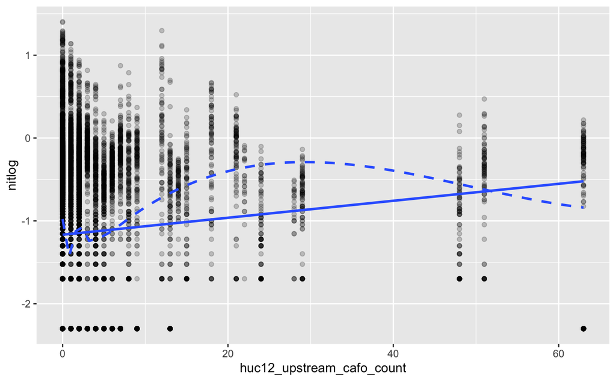

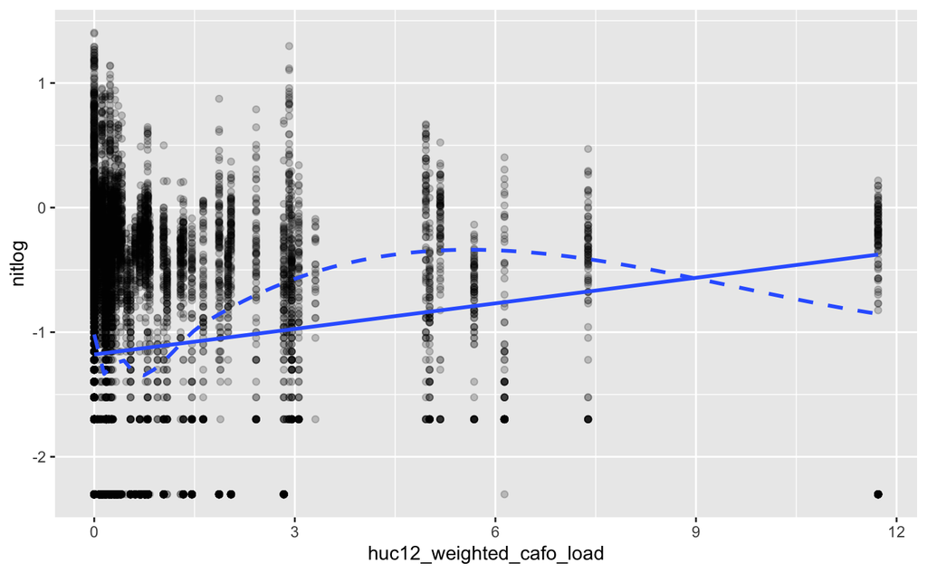

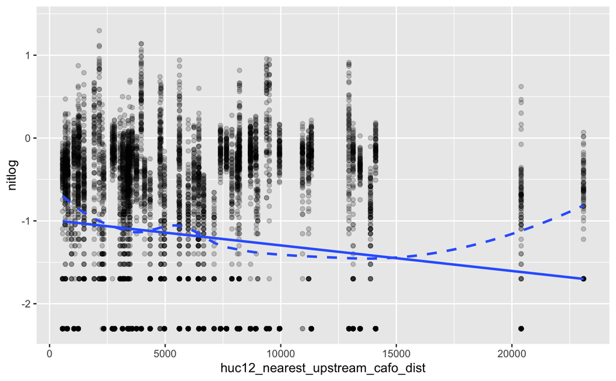

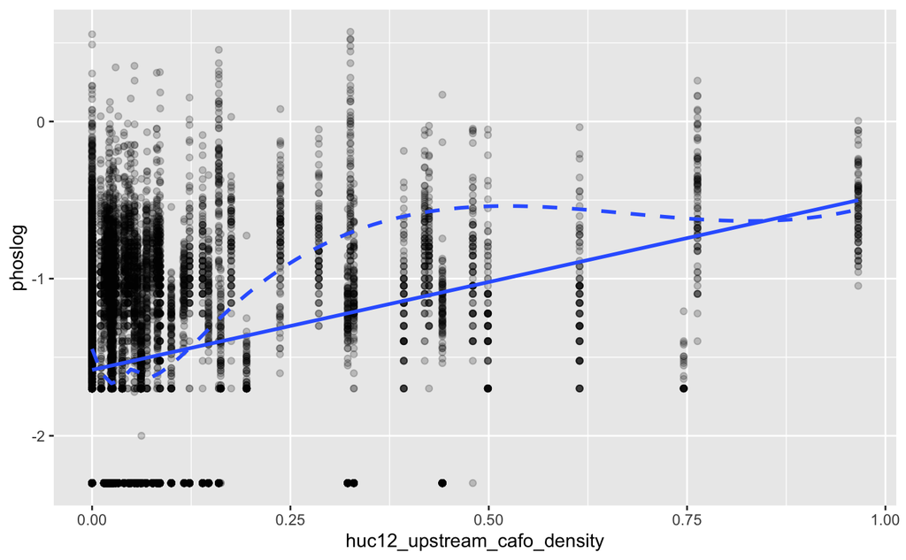

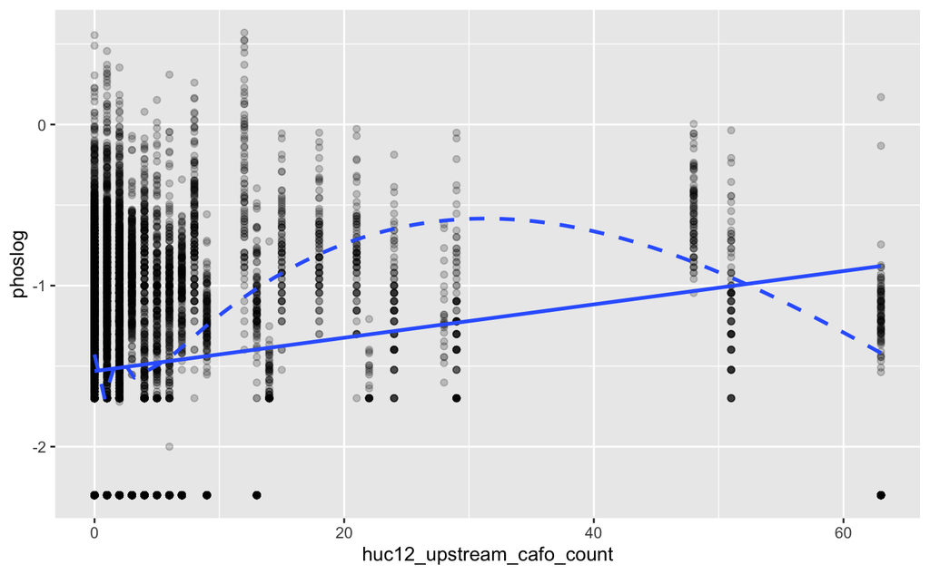

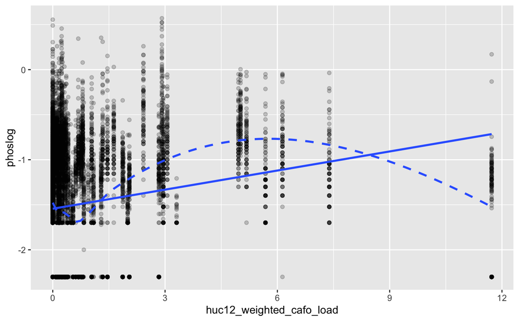

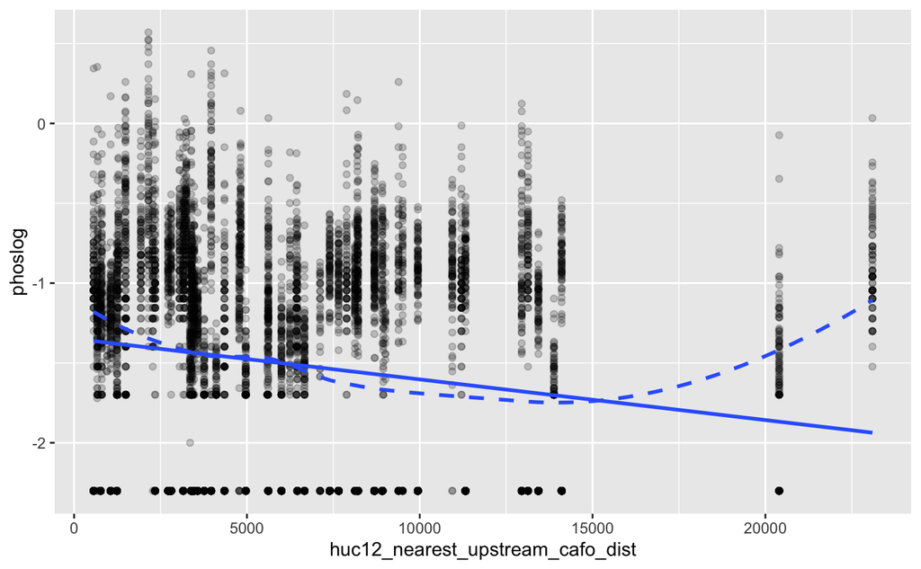

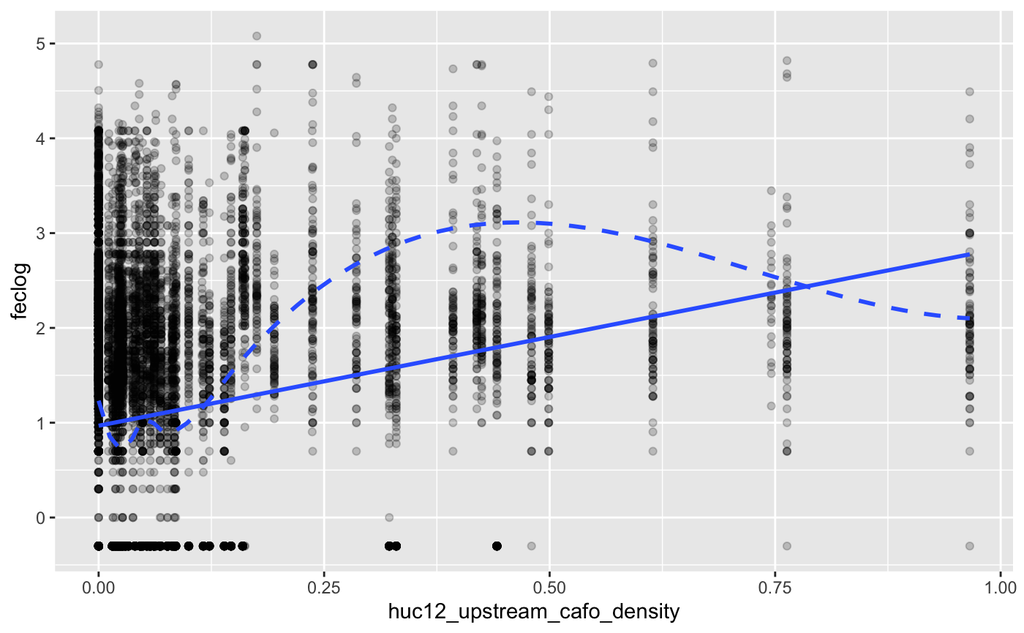

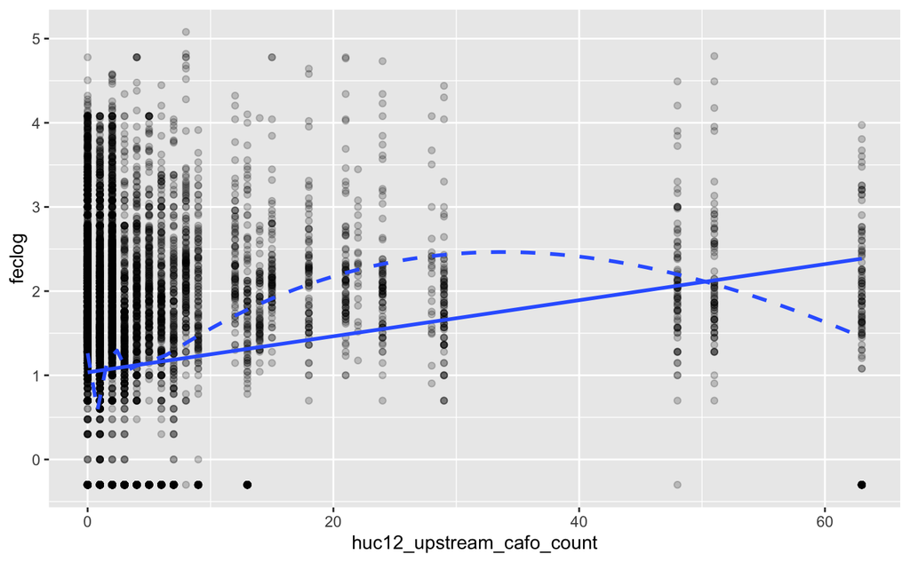

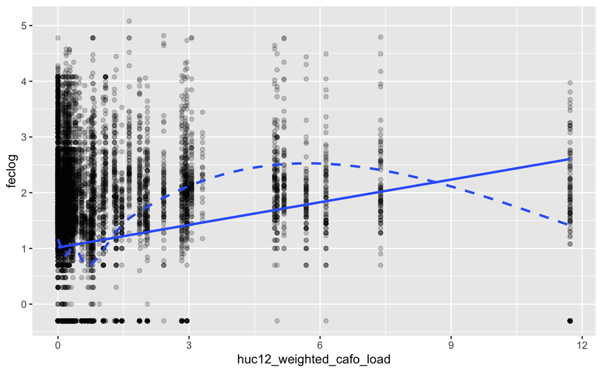

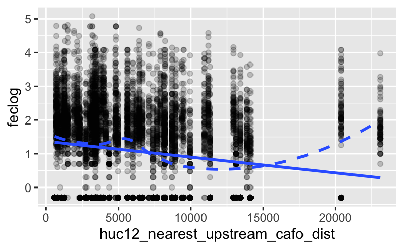

```r
# response vars
responses <- c('nitlog', 'phoslog', 'feclog')

# CAFO metrics
metrics <- c(
  'huc12_upstream_cafo_density',
  'huc12_upstream_cafo_count',
  'huc12_weighted_cafo_load',
  'huc12_nearest_upstream_cafo_dist'
)

# make all plots
plots <- list()

for (response in responses) {
  for (metric in metrics) {

    plots[[length(plots) + 1]] <- make_plot(
      data = df,
      x_var = metric,
      y_var = response
    )
  }
}

plots
```

Note from the analysis plan doc shared by Dr. Ercumen: ‘The analysis should consider multiple spatial scales and disentangle associations with poultry CAFOs vs. all CAFOs combined. We can consider using these in their continuous form if the relationship with the response variable is linear, otherwise need categorical variables (e.g. quintiles)’